# Interactions, then Datasets/APIs

STAT 230

3/2/2017

## ATUS

Load in the dataset:

```r
# x <- read.csv("atus_social.csv", as.is = TRUE)
x <- read.csv("https://www.dropbox.com/s/c7gidc2stjh3a2k/atus_social.csv?raw=1",
              as.is = TRUE)
head(x)
```

```
##      tucaseid age sex                      edu       race hispanic metro
## 1 2.01401e+13  20   F   2. high school diploma White only      Yes   Yes
## 2 2.01401e+13  16   F 1. < high school diploma Black only       No   Yes
## 3 2.01401e+13  65   F 1. < high school diploma White only      Yes   Yes
## 4 2.01401e+13  50   F   2. high school diploma Black only       No    No
## 5 2.01401e+13  23   F   2. high school diploma Black only       No    No
## 6 2.01401e+13  85   M 1. < high school diploma Black only       No   Yes
##   social_time num_children weekly_earn diary_date              famincome
## 1          30            1          NA   20140126            1. < $5,000
## 2         200            1     1846.15   20140130 11. $40,000 to $49,999
## 3         255            3          NA   20140127 10. $35,000 to $39,999
## 4         460            0          NA   20140126            1. < $5,000
## 5         120            1          NA   20140129    3. $7,500 to $9,999
## 6        1140            0          NA   20140126 13. $60,000 to $74,999
##   hh_size
## 1       1
## 2       2
## 3       6
## 4       1
## 5       2
## 6       2
```

## Incorporating Diary Date

```r
head(x$diary_date)
```

```
## [1] 20140126 20140130 20140127 20140126 20140129 20140126
```

```r
class(x$diary_date)
```

```
## [1] "integer"
```

```r
#install.packages("lubridate")
library(lubridate)
x$diary_date <- ymd(x$diary_date)
head(x$diary_date)
```

```
## [1] "2014-01-26" "2014-01-30" "2014-01-27" "2014-01-26" "2014-01-29"
## [6] "2014-01-26"
```

```r
class(x$diary_date)
```

```
## [1] "Date"
```

```r
x$wday <- wday(x$diary_date)
table(x$wday)
```

```
##
##    1    2    3    4    5    6    7
## 2864 1108 1142 1122 1091 1113 2679
```

```r
x$wday <- factor(wday(x$diary_date, label=TRUE), ordered=FALSE)
table(x$wday)
```

```
##
##   Sun   Mon  Tues   Wed Thurs   Fri   Sat
##  2864  1108  1142  1122  1091  1113  2679
```

```r
class(x$wday)
```

```
## [1] "factor"
```

```r
m4 <- lm(social_time ~ age + I(age^2) + sex + wday, data=x)
head(model.matrix(m4))
```

```
##   (Intercept) age I(age^2) sexM wdayMon wdayTues wdayWed wdayThurs wdayFri
## 1           1  20      400    0       0        0       0         0       0
## 2           1  16      256    0       0        0       0         1       0
## 3           1  65     4225    0       1        0       0         0       0
## 4           1  50     2500    0       0        0       0         0       0
## 5           1  23      529    0       0        0       1         0       0
## 6           1  85     7225    1       0        0       0         0       0
##   wdaySat
## 1       0
## 2       0
## 3       0
## 4       0
## 5       0
## 6       0
```

A categorical variable with $K$ levels can be encoded using $K-1$ dummy variables (indicators). These $K-1$ indicators are not independent: for each row, at most one of them will have the value 1, while the others will be 0’s. If there are no 1’s, then we know that the row corresponds to the baseline reference level (here that would be Sunday, since there is no explicit indicator for Sundays).

```r
summary(m4)
```

```
##
## Call:
## lm(formula = social_time ~ age + I(age^2) + sex + wday, data = x)
##
## Residuals:
##    Min     1Q Median     3Q    Max
## -576.2 -141.1  -31.1  116.1 1085.7
##
## Coefficients:
##               Estimate Std. Error t value Pr(>|t|)
## (Intercept) 402.899556  13.415876  30.032   <2e-16 ***
## age          -8.139729   0.557168 -14.609   <2e-16 ***
## I(age^2)      0.118764   0.005528  21.485   <2e-16 ***
## sexM         42.641456   3.782602  11.273   <2e-16 ***
## wdayMon     -86.759975   6.998111 -12.398   <2e-16 ***
## wdayTues    -93.692871   6.923076 -13.533   <2e-16 ***
## wdayWed     -91.402053   6.966500 -13.120   <2e-16 ***
## wdayThurs   -99.460546   7.037803 -14.132   <2e-16 ***
## wdayFri     -61.403509   6.986859  -8.788   <2e-16 ***
## wdaySat       7.064279   5.318063   1.328    0.184
## ---
## Signif. codes:  0 '***' 0.001 '**' 0.01 '*' 0.05 '.' 0.1 ' ' 1
##
## Residual standard error: 197.8 on 11109 degrees of freedom
##   (231 observations deleted due to missingness)
## Multiple R-squared:  0.1735, Adjusted R-squared:  0.1729
## F-statistic: 259.2 on 9 and 11109 DF,  p-value: < 2.2e-16
```

All of the `wday` coefficients in this output are actually comparing each labeled day of the week to Sunday, our reference level. Based on the coefficients, we can see that Mondays and Thursdays are fairly similar – on average, respondents spent about 90 minutes less time socializing/relaxing on these days than on Sunday. Friday seemed to be a bit better, such that respondents spent only 60 minutes less time socializing/relaxing compared to Sunday. Saturday and Sunday are about the same – the p-value suggests that people on average spend about the same time socializing on Saturday and Sundays.

What about fitting a “Friday effect”? After all, we saw that Fridays are somewhat different from regular workdays and weekends:

```r
x$daytype <- ifelse(x$wday %in% c("Sat", "Sun"), "Wknd", "M_Th")
x$daytype[x$wday == "Fri"] <- "Fri"
table(x$daytype, x$wday)
```

```
##
##         Sun  Mon Tues  Wed Thurs  Fri  Sat
##   Fri     0    0    0    0     0 1113    0
##   M_Th    0 1108 1142 1122  1091    0    0
##   Wknd 2864    0    0    0     0    0 2679
```

```r
m5a <- lm(social_time ~ age + I(age^2) + sex + daytype, data=x)
summary(m5a)
```

```
##
## Call:
## lm(formula = social_time ~ age + I(age^2) + sex + daytype, data = x)
##
## Residuals:
##     Min      1Q  Median      3Q     Max
## -572.36 -140.94  -31.33  115.77 1084.85
##
## Coefficients:
##               Estimate Std. Error t value Pr(>|t|)
## (Intercept) 341.538743  14.248605  23.970  < 2e-16 ***
## age          -8.138435   0.557102 -14.609  < 2e-16 ***
## I(age^2)      0.118723   0.005527  21.481  < 2e-16 ***
## sexM         42.658117   3.782233  11.279  < 2e-16 ***
## daytypeM_Th -31.403852   6.627338  -4.739 2.18e-06 ***
## daytypeWknd  64.815816   6.497439   9.976  < 2e-16 ***
## ---
## Signif. codes:  0 '***' 0.001 '**' 0.01 '*' 0.05 '.' 0.1 ' ' 1
##
## Residual standard error: 197.8 on 11113 degrees of freedom
##   (231 observations deleted due to missingness)
## Multiple R-squared:  0.1732, Adjusted R-squared:  0.1728
## F-statistic: 465.7 on 5 and 11113 DF,  p-value: < 2.2e-16
```

Is this model better or worse than our model with all the days of the week?

```r
summary(m4)$r.sq
```

```
## [1] 0.1735276
```

```r
summary(m5a)$r.sq
```

```
## [1] 0.1732215
```

```r
extractAIC(m4)
```

```
## [1]     10.0 117587.4
```

```r
extractAIC(m5a)
```

```
## [1]      6.0 117583.5
```

We also considered modeling just a weekday vs. weekend effect, bundling up Fridays with the other days.

```r
x$wknd <- x$wday %in% c("Sat", "Sun")
table(x$wknd, x$wday)
```

```
##
##          Sun  Mon Tues  Wed Thurs  Fri  Sat
##   FALSE    0 1108 1142 1122  1091 1113    0
##   TRUE  2864    0    0    0     0    0 2679
```

```r
m5 <- lm(social_time ~ age + I(age^2) + sex + wknd, data=x)
summary(m5)
```

```
##
## Call:
## lm(formula = social_time ~ age + I(age^2) + sex + wknd, data = x)
##
## Residuals:
##     Min      1Q  Median      3Q     Max
## -572.52 -141.03  -30.59  115.96 1078.59
##
## Coefficients:
##               Estimate Std. Error t value Pr(>|t|)
## (Intercept) 316.172628  13.217526   23.92   <2e-16 ***
## age          -8.131190   0.557637  -14.58   <2e-16 ***
## I(age^2)      0.118692   0.005532   21.45   <2e-16 ***
## sexM         42.566350   3.785832   11.24   <2e-16 ***
## wkndTRUE     89.952847   3.755373   23.95   <2e-16 ***
## ---
## Signif. codes:  0 '***' 0.001 '**' 0.01 '*' 0.05 '.' 0.1 ' ' 1
##
## Residual standard error: 198 on 11114 degrees of freedom
##   (231 observations deleted due to missingness)
## Multiple R-squared:  0.1716, Adjusted R-squared:  0.1713
## F-statistic: 575.4 on 4 and 11114 DF,  p-value: < 2.2e-16
```

You should review notes from last class to see how this model translates into a fitted equation.

How does this model compare to the previous one?

```r
summary(m5a)$r.sq
```

```
## [1] 0.1732215
```

```r
summary(m5)$r.sq
```

```
## [1] 0.171551
```

```r
extractAIC(m5a)
```

```
## [1]      6.0 117583.5
```

```r
extractAIC(m5)
```

```
## [1]      5.0 117603.9
```

In summary, if we were using AIC as the measure for comparison, we would prefer the model that breaks the relationship down into a Monday-Thursday, Friday, and a Weekend effect. This means that our model is fitting 6 parallel parabolas.

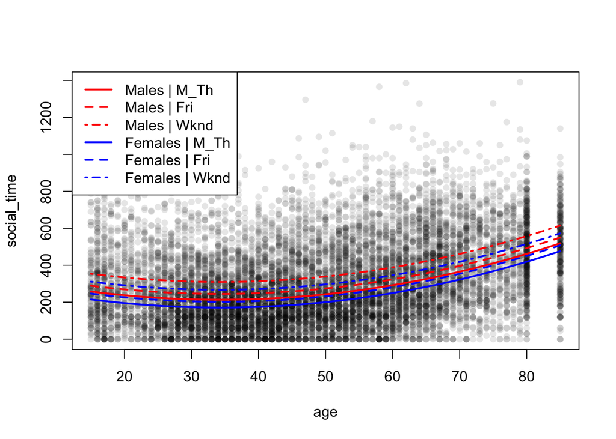

```r
myfun <- function(sex, daytype, model) {
  vals <- predict(model, data.frame(age = 15:85, sex = sex, daytype = daytype))
  return(vals)
}

plot(social_time ~ age, data=x, pch=16, col=rgb(0,0,0,0.1))
lines(15:85, myfun("M", "M_Th", m5a), col="red", lwd=2)
lines(15:85, myfun("M", "Fri", m5a), col="red", lwd=2, lty=2)
lines(15:85, myfun("M", "Wknd", m5a), col="red", lwd=2, lty=4)
lines(15:85, myfun("F", "M_Th", m5a), col="blue", lwd=2)
lines(15:85, myfun("F", "Fri", m5a), col="blue", lwd=2, lty=2)
lines(15:85, myfun("F", "Wknd", m5a), col="blue", lwd=2, lty=4)

legend("topleft", col=rep(c("red", "blue"), each=3), lwd=2, lty=rep(c(1,2,4),
                                                                    times=2),
       legend=c("Males | M_Th", "Males | Fri", "Males | Wknd",
                "Females | M_Th", "Females | Fri", "Females | Wknd"))
```

Suppose we want to interact sex and daytype to allow for, say, weekends to affect time spent socializing differently between males and females:

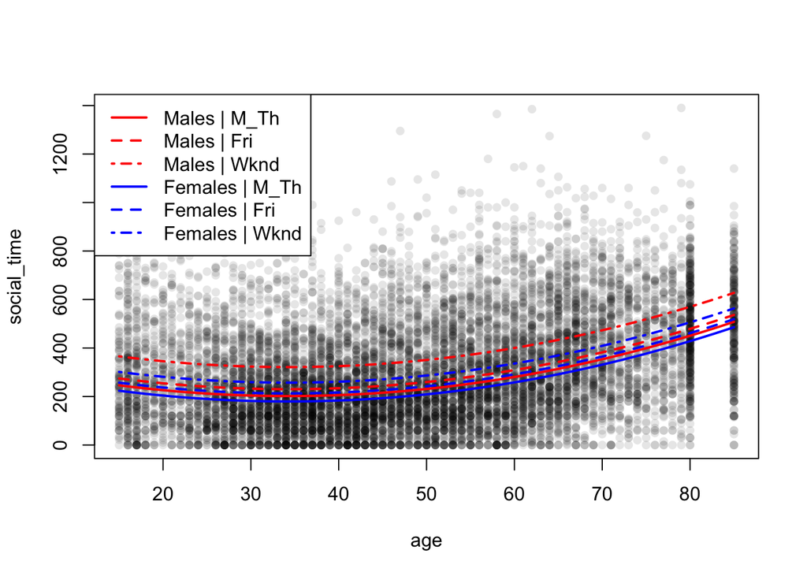

```r
m6 <- lm(social_time ~ age + I(age^2) + sex * daytype, data = x)


plot(social_time ~ age, data=x, pch=16, col=rgb(0,0,0,0.1))
lines(15:85, myfun("M", "M_Th", m6), col="red", lwd=2)
lines(15:85, myfun("M", "Fri", m6), col="red", lwd=2, lty=2)
lines(15:85, myfun("M", "Wknd", m6), col="red", lwd=2, lty=4)
lines(15:85, myfun("F", "M_Th", m6), col="blue", lwd=2)
lines(15:85, myfun("F", "Fri", m6), col="blue", lwd=2, lty=2)
lines(15:85, myfun("F", "Wknd", m6), col="blue", lwd=2, lty=4)

legend("topleft", col=rep(c("red", "blue"), each=3), lwd=2, lty=rep(c(1,2,4),
                                                                    times=2),
       legend=c("Males | M_Th", "Males | Fri", "Males | Wknd",
                "Females | M_Th", "Females | Fri", "Females | Wknd"))
```

```r
summary(m6)
```

```
##
## Call:
## lm(formula = social_time ~ age + I(age^2) + sex * daytype, data = x)
##
## Residuals:
##     Min      1Q  Median      3Q     Max
## -563.28 -139.88  -30.78  114.26 1096.28
##
## Coefficients:
##                   Estimate Std. Error t value Pr(>|t|)
## (Intercept)      352.76750   15.04421  23.449  < 2e-16 ***
## age               -8.16180    0.55636 -14.670  < 2e-16 ***
## I(age^2)           0.11903    0.00552  21.564  < 2e-16 ***
## sexM              17.46573   11.95005   1.462 0.143890
## daytypeM_Th      -33.24514    8.80464  -3.776 0.000160 ***
## daytypeWknd       44.30694    8.63381   5.132 2.92e-07 ***
## sexM:daytypeM_Th   4.71739   13.34964   0.353 0.723816
## sexM:daytypeWknd  46.71496   13.08726   3.570 0.000359 ***
## ---
## Signif. codes:  0 '***' 0.001 '**' 0.01 '*' 0.05 '.' 0.1 ' ' 1
##
## Residual standard error: 197.5 on 11111 degrees of freedom
##   (231 observations deleted due to missingness)
## Multiple R-squared:  0.1756, Adjusted R-squared:  0.1751
## F-statistic: 338.2 on 7 and 11111 DF,  p-value: < 2.2e-16
```

Equation for predicting how much time males spend socializing on Mondays through Thursdays:

$$\widehat{socialtime} = 353 - 8.16 age + .119 age^2 + 17.47 - 33.2 + 4.717 = 342 - 8.16 age + .119 age^2$$

It’s hard to interpret the `sexM:daytypeM_Th` coefficient of 4.72 in isolation. It might be more helpful to note that we have a total of 6 intercept-type coefficients, so effectively we have 6 degrees of freedom to fit intercepts for 6 different parabolas as seen in the plot.

Note that the `sexM:daytypeM_Th` variable has a large p-value, suggesting that we don’t have enough evidence to reject $H_0: \beta_{\text{sexM:daytypeMTh}} = 0$. The other interaction coefficient is actually statistically significant. We can’t just keep the one that is significant in the model.

### F-statistics

In the regression summary, the F-statistic at the bottom is simultaneously testing whether any of the non-intercept coefficients are statistically significant.

$$H_0: \beta_{age} =\beta_{age^2} = ... = \beta_{sexM:daytypeWknd} = 0$$

$$H_a: \text{ at least one of these }\beta_j \ne 0$$

```r
anova(m6)
```

```
## Analysis of Variance Table
##
## Response: social_time
##                Df    Sum Sq  Mean Sq  F value    Pr(>F)
## age             1  44972545 44972545 1152.674 < 2.2e-16 ***
## I(age^2)        1  17684672 17684672  453.269 < 2.2e-16 ***
## sex             1   5065309  5065309  129.827 < 2.2e-16 ***
## daytype         2  23368685 11684342  299.477 < 2.2e-16 ***
## sex:daytype     2   1269236   634618   16.266 8.836e-08 ***
## Residuals   11111 433505175    39016
## ---
## Signif. codes:  0 '***' 0.001 '**' 0.01 '*' 0.05 '.' 0.1 ' ' 1
```

This command provides us p-values that test the significance of individual predictors (and in cases where the predictor is associated with 2 or more coefficients, we get a single p-value that considers all coefficients).

```r
summary(m5a)$r.squared
```

```
## [1] 0.1732215
```

```r
summary(m6)$r.squared
```

```
## [1] 0.1756351
```

## Movie Data

Pre-requisite packages:

```r
library(XML)
library(omdbapi)
```

If the above packages don’t load, you will need to install the following packages:

```r
install.packages("XML")
install.packages("devtools")
devtools::install_github("hrbrmstr/omdbapi")
```

### Part 1

For this first part, we’d like to scrape the top 250 movies at the International Movies Database (IMDB) website here:

> http://www.imdb.com/chart/top

By scraping, we really mean that we want a representation of this dataset that is readable in R (say, as a data frame). Then, we can examine how movie ratings vary by year of release, for example. Or we can use an alternative data source to merge in additional variables that might be of interest to us.

The XML package has a number of functions that can be used to extract structured data from the web. Our data resides in an HTML table. Because an HTML table is pretty well-structured, we can use the `readHTMLTable()` to extract the information in this table into R.

```r
imdb <- readHTMLTable("http://www.imdb.com/chart/top",
                      which=1, stringsAsFactors = FALSE)
head(imdb)
```

```
##                                          Rank & Title IMDb Rating
## 1  1.\n      The Shawshank Redemption\n        (1994)         9.2
## 2             2.\n      The Godfather\n        (1972)         9.2
## 3    3.\n      The Godfather: Part II\n        (1974)         9.0
## 4           4.\n      The Dark Knight\n        (2008)         8.9
## 5              5.\n      12 Angry Men\n        (1957)         8.9
## 6          6.\n      Schindler's List\n        (1993)         8.9
##                                                                                                                  Your Rating
## 1 12345678910\n        \n        \n            \n            NOT YET RELEASED\n             \n            \n            Seen
## 2 12345678910\n        \n        \n            \n            NOT YET RELEASED\n             \n            \n            Seen
## 3 12345678910\n        \n        \n            \n            NOT YET RELEASED\n             \n            \n            Seen
## 4 12345678910\n        \n        \n            \n            NOT YET RELEASED\n             \n            \n            Seen
## 5 12345678910\n        \n        \n            \n            NOT YET RELEASED\n             \n            \n            Seen
## 6 12345678910\n        \n        \n            \n            NOT YET RELEASED\n             \n            \n            Seen
##
## 1
## 2
## 3
## 4
## 5
## 6
```

```r
colnames(imdb)
```

```
## [1] ""             "Rank & Title" "IMDb Rating"  "Your Rating"
## [5] ""
```

```r
imdb <- imdb[,2:3] # only really need the 2nd and 3rd columns
head(imdb)
```

```
##                                         Rank & Title IMDb Rating
## 1 1.\n      The Shawshank Redemption\n        (1994)         9.2
## 2            2.\n      The Godfather\n        (1972)         9.2
## 3   3.\n      The Godfather: Part II\n        (1974)         9.0
## 4          4.\n      The Dark Knight\n        (2008)         8.9
## 5             5.\n      12 Angry Men\n        (1957)         8.9
## 6         6.\n      Schindler's List\n        (1993)         8.9
```

Data scraped from the web will typically have some degree of messiness that needs to be cleaned. In this case, we can see that the first column of the dataset is informative, but is a bit too heterogeneous for us to work with. We’ll now take a sequence of steps to parse this out into a `title` column and a `year` column.

```r
title_years <- strsplit(imdb[,1], "\n")
head(title_years)
```

```
## [[1]]
## [1] "1."                             "      The Shawshank Redemption"
## [3] "        (1994)"
##
## [[2]]
## [1] "2."                  "      The Godfather" "        (1972)"
##
## [[3]]
## [1] "3."                           "      The Godfather: Part II"
## [3] "        (1974)"
##
## [[4]]
## [1] "4."                    "      The Dark Knight" "        (2008)"
##
## [[5]]
## [1] "5."                 "      12 Angry Men" "        (1957)"
##
## [[6]]
## [1] "6."                     "      Schindler's List"
## [3] "        (1993)"
```

```r
class(title_years)
```

```
## [1] "list"
```

```r
title_years <- unlist(title_years)
head(title_years)
```

```
## [1] "1."                             "      The Shawshank Redemption"
## [3] "        (1994)"                 "2."
## [5] "      The Godfather"            "        (1972)"
```

```r
class(title_years)
```

```
## [1] "character"
```

```r
imdb$year <- title_years[seq(3, length(title_years), 3)]
head(imdb$year)
```

```
## [1] "        (1994)" "        (1972)" "        (1974)" "        (2008)"
## [5] "        (1957)" "        (1993)"
```

```r
imdb$title <- title_years[seq(2, length(title_years), 3)]
head(imdb)
```

```
##                                         Rank & Title IMDb Rating
## 1 1.\n      The Shawshank Redemption\n        (1994)         9.2
## 2            2.\n      The Godfather\n        (1972)         9.2
## 3   3.\n      The Godfather: Part II\n        (1974)         9.0
## 4          4.\n      The Dark Knight\n        (2008)         8.9
## 5             5.\n      12 Angry Men\n        (1957)         8.9
## 6         6.\n      Schindler's List\n        (1993)         8.9
##             year                          title
## 1         (1994)       The Shawshank Redemption
## 2         (1972)                  The Godfather
## 3         (1974)         The Godfather: Part II
## 4         (2008)                The Dark Knight
## 5         (1957)                   12 Angry Men
## 6         (1993)               Schindler's List
```

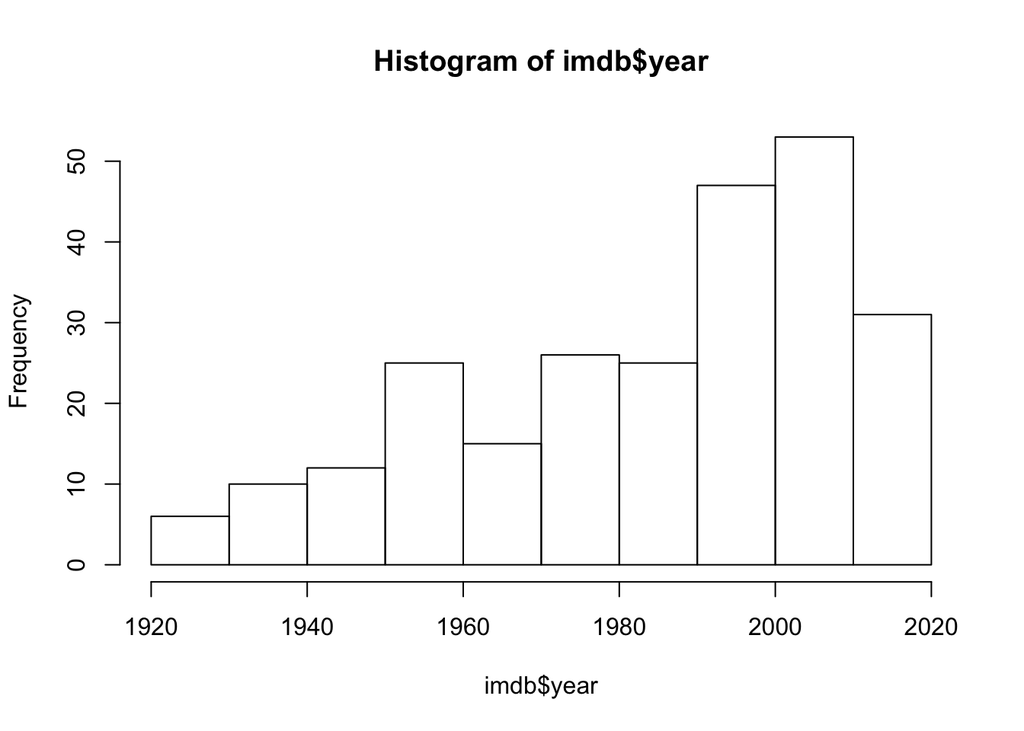

```r
imdb$year <- trimws(imdb$year)
imdb$year <- substr(imdb$year, 2, 5)
imdb$year <- as.numeric(imdb$year)
hist(imdb$year)
```

```r
summary(imdb$year)
```

```
##    Min. 1st Qu.  Median    Mean 3rd Qu.    Max.
##    1921    1966    1993    1985    2004    2016
```

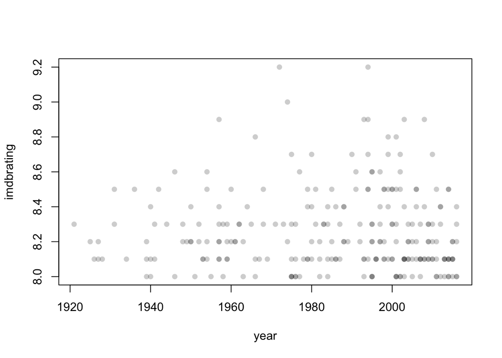

```r
imdb$title <- trimws(imdb$title)
imdb <- imdb[,-1]
imdb$rank <- 1:250

colnames(imdb)[1] <- "imdbrating"

plot(imdbrating ~ year, data=imdb, col=rgb(0, 0, 0, 0.2), pch=16)
```

### Part 2: using the API

An API is a tool that allows software such as R or Python communicate with a server to obtain information directly. Not all websites with interesting data have their own API. For example, IMDb did not have an API, so we had to take the manual route in Part 1 to scrape the data. While that was helpful for obtaining some information about movies, we might be interested in other bits of information. Thankfully, an Open Movies Database (OMDB) exists with other pieces of information we might be interested in about any movies and someone has written an API for it to speak directly with R!

One way to access a movie’s data via the `omdbapi` is to locate it by the name of the movie as well as the release year.

```r
library(omdbapi)

movie <- find_by_title(imdb$title[2], year_of_release = imdb$year[2],
              include_tomatoes = TRUE)
names(movie)
```

```
##  [1] "Title"             "Year"              "Rated"
##  [4] "Released"          "Runtime"           "Genre"
##  [7] "Director"          "Writer"            "Actors"
## [10] "Plot"              "Language"          "Country"
## [13] "Awards"            "Poster"            "Metascore"
## [16] "imdbRating"        "imdbVotes"         "imdbID"
## [19] "Type"              "tomatoMeter"       "tomatoImage"
## [22] "tomatoRating"      "tomatoReviews"     "tomatoFresh"
## [25] "tomatoRotten"      "tomatoConsensus"   "tomatoUserMeter"
## [28] "tomatoUserRating"  "tomatoUserReviews" "tomatoURL"
## [31] "DVD"               "BoxOffice"         "Production"
## [34] "Website"           "Response"
```

```r
movie
```

```
##             Title: The Godfather
##              Year: 1972
##             Rated: R
##          Released: 1972-03-24
##           Runtime: 175 min
##             Genre: Crime, Drama
##          Director: Francis Ford Coppola
##            Writer: Mario Puzo (screenplay), Francis Ford Coppola (screenplay), Mario
##                    Puzo (novel)
##            Actors: Marlon Brando, Al Pacino, James Caan, Richard S. Castellano
##              Plot: The aging patriarch of an organized crime dynasty transfers
##                    control of his clandestine empire to his reluctant son.
##          Language: English, Italian, Latin
##           Country: USA
##            Awards: Won 3 Oscars. Another 23 wins & 27 nominations.
##            Poster: https://images-na.ssl-images-amazon.com/images/M/
##                    MV5BZTRmNjQ1ZDYtNDgzMy00OGE0LWE4N2YtNTkzNWQ5ZDhlNGJmL2ltYWdlL2ltYWdlXkEyXkFqcGdeQXVyNjU0OTQ0OTY@._V1_SX300.jpg
##         Metascore: 100
##        imdbRating: 9.2
##         imdbVotes: 1209397
##            imdbID: tt0068646
##              Type: movie
##       tomatoMeter: 99
##       tomatoImage: certified
##      tomatoRating: 9.2
##     tomatoReviews: 84
##       tomatoFresh: 83
##      tomatoRotten: 1
##   tomatoConsensus: One of Hollywood's greatest critical and commercial successes,
##                    The Godfather gets everything right; not only did the movie
##                    transcend expectations, it established new benchmarks for
##                    American cinema.
##   tomatoUserMeter: 98
##  tomatoUserRating: 4.4
## tomatoUserReviews: 728802
##               DVD: 2001-10-09
##         BoxOffice: N/A
##        Production: Paramount Pictures
##           Website: http://www.thegodfather.com
```

Some relevant info we might want about this movie:

```r
c(movie$Rated, movie$Runtime, movie$Genre, movie$tomatoRating)
```

```
## [1] "R"            "175 min"      "Crime, Drama" "9.2"
```

Now, since we’ve proven that we can extract some useful information about a single movie, we can write a loop to extract information about all 250 movies.

```r
movieMat <- matrix(NA, nrow=250, ncol=4)
for (i in 1:nrow(imdb)) {
  movie <- find_by_title(imdb$title[i],
                         year_of_release = imdb$year[i],
              include_tomatoes = TRUE)
  if (length(movie) != 0) {
    movieMat[i,] <- c(movie$Rated, movie$Runtime, movie$Genre, movie$tomatoRating)
  }
}
```

```
## Movie not found!
## Movie not found!
## Movie not found!
## Movie not found!
## Movie not found!
## Movie not found!
```

```r
head(movieMat)
```

```
##      [,1]       [,2]      [,3]                        [,4]
## [1,] "R"        "142 min" "Crime, Drama"              "8.2"
## [2,] "R"        "175 min" "Crime, Drama"              "9.2"
## [3,] "R"        "202 min" "Crime, Drama"              "9.5"
## [4,] "PG-13"    "152 min" "Action, Crime, Drama"      "8.6"
## [5,] "APPROVED" "96 min"  "Crime, Drama"              "8.9"
## [6,] "R"        "195 min" "Biography, Drama, History" "9"
```

Merging the two datasets.

```r
imdb$rated <- movieMat[,1]
imdb$genre <- movieMat[,3]
imdb$tomatorating <- as.numeric(movieMat[,4])
head(imdb)
```

```
##   imdbrating year                    title rank    rated
## 1        9.2 1994 The Shawshank Redemption    1        R
## 2        9.2 1972            The Godfather    2        R
## 3        9.0 1974   The Godfather: Part II    3        R
## 4        8.9 2008          The Dark Knight    4    PG-13
## 5        8.9 1957             12 Angry Men    5 APPROVED
## 6        8.9 1993         Schindler's List    6        R
##                       genre tomatorating
## 1              Crime, Drama          8.2
## 2              Crime, Drama          9.2
## 3              Crime, Drama          9.5
## 4      Action, Crime, Drama          8.6
## 5              Crime, Drama          8.9
## 6 Biography, Drama, History          9.0
```